# Lab 6 - La Quinta is Spanish for next to Denny’s, Pt. 1

Visualizing spatial data

salma ali

Student ID: 2201002881

Load the needed packages. Note: dsbox is not yet on CRAN. For now, you need to install it before you load the library. Uncomment, by deleting # from, the two lines of code below.

```r
install.packages("devtools")
devtools::install_github("rstudio-education/dsbox")
```

Load the libraries here.

```r
library(tidyverse)
library(dsbox)
```

To help with our analysis we will also use a dataset on US states, which is located in your repository’s `data` folder.

```r
states <- read_csv("data/states.csv")
```

# Exercises

1. What are the dimensions of the Denny’s dataset? (Hint: Use inline R code and functions like `nrow` and `ncol` to compose your answer.) What does each row in the dataset represent? What are the variables?

```r
dim(dennys)
```

```
## [1] 1643    6
```

```r
head(dennys)
```

| address | city | state | zip | longitude | latitude |
| --- | --- | --- | --- | --- | --- |
| 2900 Denali | Anchorage | AK | 99503 | -149.8767 | 61.1953 |
| 3850 Debarr Road | Anchorage | AK | 99508 | -149.8090 | 61.2097 |
| 1929 Airport Way | Fairbanks | AK | 99701 | -147.7600 | 64.8366 |
| 230 Connector Dr | Auburn | AL | 36849 | -85.4681 | 32.6033 |
| 224 Daniel Payne Drive N | Birmingham | AL | 35207 | -86.8317 | 33.5615 |
| 900 16th St S, Commons on Gree | Birmingham | AL | 35294 | -86.8037 | 33.5007 |

2. What are the dimensions of the La Quinta’s dataset? What does each row in the dataset represent? What are the variables?

```r
dim(laquinta)
```

```
## [1] 909   6
```

```r
head(laquinta)
```

| address | city | state | zip | longitude | latitude |
| --- | --- | --- | --- | --- | --- |
| 793 W. Bel Air Avenue | \nAberdeen | MD | 21001 | -76.18846 | 39.52322 |
| 3018 CatClaw Dr | \nAbilene | TX | 79606 | -99.77877 | 32.41349 |
| 3501 West Lake Rd | \nAbilene | TX | 79601 | -99.72269 | 32.49136 |
| 184 North Point Way | \nAcworth | GA | 30102 | -84.65609 | 34.08204 |
| 2828 East Arlington Street | \nAda | OK | 74820 | -96.63652 | 34.78180 |
| 14925 Landmark Blvd | \nAddison | TX | 75254 | -96.82874 | 32.95164 |

Knit, *commit, and push your changes to GitHub with an appropriate commit message. Make sure to commit and push all changed files so that your Git pane is cleared up afterwards.*

3. Add a country variable to the Denny’s and Laquinta’s datasets and set all observations equal to `"United States"`. Remember, you can use the `mutate` function for adding a variable. Make sure to save the result of this as `dn` and lq, respectively, so that the stored data frame contains the new variable going forward.

For Denny’s

```r
dn <- dennys %>%
    mutate(country = "United States")
```

For La Quinta

```r
lq <- laquinta %>%
    mutate(country = "United States")
```

Knit, *commit, and push your changes to GitHub with an appropriate commit message. Make sure to commit and push all changed files so that your Git pane is cleared up afterwards.*

4. Which states have the most and fewest Denny’s locations? What about La Quinta? Is this surprising? Why or why not?

For Denny’s - Most

```r
dn %>%
    count(state) %>%
    arrange(desc(n))
```

| state | n |
| --- | --- |
| CA | 403 |
| TX | 200 |
| FL | 140 |
| AZ | 83 |
| IL | 56 |
| NY | 56 |
| WA | 49 |
| OH | 44 |
| MO | 42 |
| PA | 40 |

[output cut: 41 more lines]

For Denny’s - Fewest

```r
dn %>%
    count(state) %>%
    arrange((n))
```

| state | n |
| --- | --- |
| DE | 1 |
| DC | 2 |
| VT | 2 |
| AK | 3 |
| IA | 3 |
| NH | 3 |
| SD | 3 |
| WV | 3 |
| LA | 4 |
| MT | 4 |

[output cut: 41 more lines]

For La Quinta - Most

```r
lq %>%
    count(state) %>%
    arrange(desc(n))
```

| state | n |
| --- | --- |
| TX | 237 |
| FL | 74 |
| CA | 56 |
| GA | 41 |
| TN | 30 |
| OK | 29 |
| LA | 28 |
| CO | 27 |
| NM | 19 |
| NY | 19 |

[output cut: 49 more lines]

For La Quinta - Fewest

```r
lq %>%
    count(state) %>%
    arrange((n))
```

| state | n |
| --- | --- |
| AG | 1 |
| ANT | 1 |
| BC | 1 |
| CH | 1 |
| FM | 1 |
| ME | 1 |
| ON | 1 |
| QR | 1 |
| SL | 1 |
| VE | 1 |

[output cut: 49 more lines]

5. Which states have the most Denny’s locations per thousand square miles? What about La Quinta?

Joining Denny’s and states

```r
dn %>%
  count(state) %>%
  inner_join(states, by = c("state" = "abbreviation"))
```

| state | n | name | area |
| --- | --- | --- | --- |
| AK | 3 | Alaska | 665384.04 |
| AL | 7 | Alabama | 52420.07 |
| AR | 9 | Arkansas | 53178.55 |
| AZ | 83 | Arizona | 113990.30 |
| CA | 403 | California | 163694.74 |
| CO | 29 | Colorado | 104093.67 |
| CT | 12 | Connecticut | 5543.41 |
| DC | 2 | District of Columbia | 68.34 |
| DE | 1 | Delaware | 2488.72 |
| FL | 140 | Florida | 65757.70 |

[output cut: 41 more lines]

Joining La Quinta’s and states

```r
lq %>%
  count(state) %>%
  inner_join(states, by = c("state" = "abbreviation"))
```

| state | n | name | area |
| --- | --- | --- | --- |
| AK | 2 | Alaska | 665384.04 |
| AL | 16 | Alabama | 52420.07 |
| AR | 13 | Arkansas | 53178.55 |
| AZ | 18 | Arizona | 113990.30 |
| CA | 56 | California | 163694.74 |
| CO | 27 | Colorado | 104093.67 |
| CT | 6 | Connecticut | 5543.41 |
| FL | 74 | Florida | 65757.70 |
| GA | 41 | Georgia | 59425.15 |
| IA | 4 | Iowa | 56272.81 |

[output cut: 38 more lines]

We need to add an identifier variable which we’ll call `establishment` and set the value to `"Denny's"` and `"La Quinta"` for the `dn` and `lq` data frames, respectively.

```r
dn <- dn %>%
  mutate(establishment = "Denny's")
```

```r
lq <- lq %>%
  mutate(establishment = "La Quinta")
```

Since the two data frames (`dn` and `lq`) have the same columns, we can easily bind them with the `bind_rows` function:

```r
dn_lq <- bind_rows(dn, lq)
```

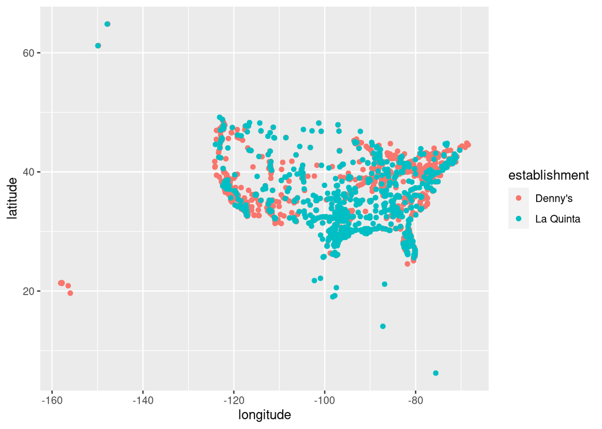

```r
ggplot(dn_lq, mapping = aes(x = longitude, y = latitude, color = establishment)) +
    geom_point()
```

Knit, *commit, and push your changes to GitHub with an appropriate commit message. Make sure to commit and push all changed files so that your Git pane is cleared up afterwards and review the md document on GitHub to make sure you’re happy with the final state of your work.*